# Emily’s Workflow

Emily Kroft

9/23/2020

# LST Exploration

## 1

I started out by making a correlation matrix of all the variables I thought might be influencing LST. The variables that seemed to display interesting patterns were: Building Density, Canopy Cover, Impervious Cover, Distance to the River, and Income.

```r
lst.data<-read.csv("Data/shortlist_data_0813.csv")
library(GGally)
library(tidyverse)
```

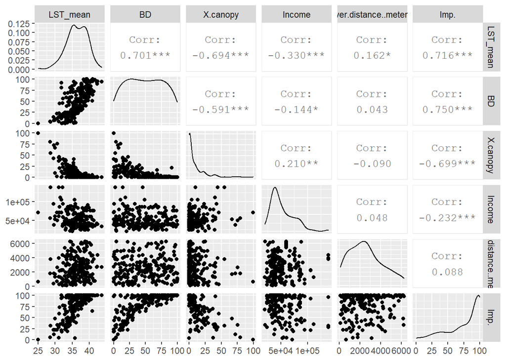

```r
data.selected<-lst.data%>%select(LST_mean,BD, X.canopy,
                                 Income,river.distance..meters.,Imp.)
GGally::ggpairs(data.selected)
```

## 2

I created an initial linear model that included all these variables, but no interactions to get an initial idea of how these variables were influencing LST. All the variables had p values <0.05 so I decided to include all of them.

Income and distance to the river were both log transformed to account for the fact that incremental differences make more of an impact at lower numbers (ie: the difference between earning 10,000/yr and 20,000/yr is a big difference but the difference between 110,000/yr vs. 120,000/yr is less significant).

```r
lst.model<-lm(LST_mean~BD+X.canopy+log(Income)+log(river.distance..meters.)+Imp., data=lst.data)
summary(lst.model)
```

```
##
## Call:
## lm(formula = LST_mean ~ BD + X.canopy + log(Income) + log(river.distance..meters.) +
##     Imp., data = lst.data)
##
## Residuals:
##     Min      1Q  Median      3Q     Max
## -5.4425 -0.7620  0.1167  1.0315  4.2303
##
## Coefficients:
##                               Estimate Std. Error t value Pr(>|t|)
## (Intercept)                  43.677133   3.417747  12.780  < 2e-16 ***
## BD                            0.037791   0.005907   6.398 9.76e-10 ***
## X.canopy                     -0.063510   0.010416  -6.098 4.97e-09 ***
## log(Income)                  -1.286202   0.301223  -4.270 2.94e-05 ***
## log(river.distance..meters.)  0.486386   0.133359   3.647 0.000333 ***
## Imp.                          0.020896   0.007568   2.761 0.006262 **
## ---
## Signif. codes:  0 '***' 0.001 '**' 0.01 '*' 0.05 '.' 0.1 ' ' 1
##
## Residual standard error: 1.66 on 214 degrees of freedom
##   (9 observations deleted due to missingness)
## Multiple R-squared:  0.701,  Adjusted R-squared:  0.694
## F-statistic: 100.3 on 5 and 214 DF,  p-value: < 2.2e-16
```

## 3

As a next step, I tried adding in some interaction terms that I thought might be important in determining LST.

The first of these was the interaction between impervious cover and canopy cover:

```r
lst.model5<-lm(LST_mean~BD+(X.canopy*Imp.)+log(Income)+log(river.distance..meters.), data=lst.data)
summary(lst.model5)
```

```
##
## Call:
## lm(formula = LST_mean ~ BD + (X.canopy * Imp.) + log(Income) +
##     log(river.distance..meters.), data = lst.data)
##
## Residuals:
##     Min      1Q  Median      3Q     Max
## -5.4392 -0.7480  0.1277  1.0283  4.2159
##
## Coefficients:
##                                Estimate Std. Error t value Pr(>|t|)
## (Intercept)                   4.369e+01  3.426e+00  12.756  < 2e-16 ***
## BD                            3.847e-02  6.331e-03   6.077 5.57e-09 ***
## X.canopy                     -6.620e-02  1.369e-02  -4.835 2.55e-06 ***
## Imp.                          1.997e-02  8.172e-03   2.444 0.015351 *
## log(Income)                  -1.285e+00  3.019e-01  -4.258 3.09e-05 ***
## log(river.distance..meters.)  4.866e-01  1.336e-01   3.641 0.000341 ***
## X.canopy:Imp.                 8.052e-05  2.651e-04   0.304 0.761644
## ---
## Signif. codes:  0 '***' 0.001 '**' 0.01 '*' 0.05 '.' 0.1 ' ' 1
##
## Residual standard error: 1.663 on 213 degrees of freedom
##   (9 observations deleted due to missingness)
## Multiple R-squared:  0.7011, Adjusted R-squared:  0.6927
## F-statistic: 83.27 on 6 and 213 DF,  p-value: < 2.2e-16
```

The second interaction I tried was between building density and canopy cover:

```r
lst.model6<-lm(LST_mean~(BD*X.canopy)+Imp.+log(Income)+log(river.distance..meters.), data=lst.data)
summary(lst.model6)
```

```
##
## Call:
## lm(formula = LST_mean ~ (BD * X.canopy) + Imp. + log(Income) +
##     log(river.distance..meters.), data = lst.data)
##
## Residuals:
##     Min      1Q  Median      3Q     Max
## -5.5190 -0.7320  0.2098  1.0594  4.3074
##
## Coefficients:
##                                Estimate Std. Error t value Pr(>|t|)
## (Intercept)                  43.7169150  3.4121824  12.812  < 2e-16 ***
## BD                            0.0379643  0.0058982   6.437 7.96e-10 ***
## X.canopy                     -0.0564101  0.0117261  -4.811 2.85e-06 ***
## Imp.                          0.0215456  0.0075717   2.846 0.004867 **
## log(Income)                  -1.2828117  0.3007316  -4.266 3.00e-05 ***
## log(river.distance..meters.)  0.4770651  0.1333265   3.578 0.000428 ***
## BD:X.canopy                  -0.0006371  0.0004864  -1.310 0.191676
## ---
## Signif. codes:  0 '***' 0.001 '**' 0.01 '*' 0.05 '.' 0.1 ' ' 1
##
## Residual standard error: 1.657 on 213 degrees of freedom
##   (9 observations deleted due to missingness)
## Multiple R-squared:  0.7034, Adjusted R-squared:  0.695
## F-statistic: 84.18 on 6 and 213 DF,  p-value: < 2.2e-16
```

Both of these interactions had quite high p values so I decided against including them in the model.

## 4

At this point, I returned to the original model to test for multicolinearity

```r
lst.model<-lm(LST_mean~BD+X.canopy+log(Income)+log(river.distance..meters.)+Imp., data=lst.data)
summary(lst.model)
```

```
##
## Call:
## lm(formula = LST_mean ~ BD + X.canopy + log(Income) + log(river.distance..meters.) +
##     Imp., data = lst.data)
##
## Residuals:
##     Min      1Q  Median      3Q     Max
## -5.4425 -0.7620  0.1167  1.0315  4.2303
##
## Coefficients:
##                               Estimate Std. Error t value Pr(>|t|)
## (Intercept)                  43.677133   3.417747  12.780  < 2e-16 ***
## BD                            0.037791   0.005907   6.398 9.76e-10 ***
## X.canopy                     -0.063510   0.010416  -6.098 4.97e-09 ***
## log(Income)                  -1.286202   0.301223  -4.270 2.94e-05 ***
## log(river.distance..meters.)  0.486386   0.133359   3.647 0.000333 ***
## Imp.                          0.020896   0.007568   2.761 0.006262 **
## ---
## Signif. codes:  0 '***' 0.001 '**' 0.01 '*' 0.05 '.' 0.1 ' ' 1
##
## Residual standard error: 1.66 on 214 degrees of freedom
##   (9 observations deleted due to missingness)
## Multiple R-squared:  0.701,  Adjusted R-squared:  0.694
## F-statistic: 100.3 on 5 and 214 DF,  p-value: < 2.2e-16
```

```r
library(car)
vif(lst.model)
```

```
##                           BD                     X.canopy
##                     2.275569                     2.069528
##                  log(Income) log(river.distance..meters.)
##                     1.062442                     1.018022
##                         Imp.
##                     3.010257
```

Canopy cover and impervious cover seemed a little correlated (the same for BD and impervious cover) so I tested a model that removed impervious cover for that reason.

```r
lst.model2<-lm(LST_mean~BD+X.canopy+log(Income)+log(river.distance..meters.), data=lst.data)
summary(lst.model2)
```

```
##
## Call:
## lm(formula = LST_mean ~ BD + X.canopy + log(Income) + log(river.distance..meters.),
##     data = lst.data)
##
## Residuals:
##     Min      1Q  Median      3Q     Max
## -5.5000 -0.7006  0.0932  0.9845  3.8559
##
## Coefficients:
##                               Estimate Std. Error t value Pr(>|t|)
## (Intercept)                  46.123739   3.351334  13.763  < 2e-16 ***
## BD                            0.047024   0.004943   9.513  < 2e-16 ***
## X.canopy                     -0.077443   0.009251  -8.372 7.27e-15 ***
## log(Income)                  -1.394660   0.303216  -4.600 7.23e-06 ***
## log(river.distance..meters.)  0.494686   0.135363   3.655 0.000324 ***
## ---
## Signif. codes:  0 '***' 0.001 '**' 0.01 '*' 0.05 '.' 0.1 ' ' 1
##
## Residual standard error: 1.685 on 215 degrees of freedom
##   (9 observations deleted due to missingness)
## Multiple R-squared:  0.6903, Adjusted R-squared:  0.6846
## F-statistic: 119.8 on 4 and 215 DF,  p-value: < 2.2e-16
```

```r
vif(lst.model2)
```

```
##                           BD                     X.canopy
##                     1.546184                     1.583695
##                  log(Income) log(river.distance..meters.)
##                     1.044374                     1.017504
```

I then conducted a few model comparisons to see if the model without impervious cover was better:

```r
anova(lst.model,lst.model2)
```

```
## Analysis of Variance Table
##
## Model 1: LST_mean ~ BD + X.canopy + log(Income) + log(river.distance..meters.) +
##     Imp.
## Model 2: LST_mean ~ BD + X.canopy + log(Income) + log(river.distance..meters.)
##   Res.Df    RSS Df Sum of Sq      F   Pr(>F)
## 1    214 589.55
## 2    215 610.56 -1   -21.002 7.6233 0.006262 **
## ---
## Signif. codes:  0 '***' 0.001 '**' 0.01 '*' 0.05 '.' 0.1 ' ' 1
```

```r
AIC(lst.model, lst.model2)
```

```
##            df      AIC
## lst.model   7 855.1958
## lst.model2  6 860.8965
```

Based on the importance of impervious cover that has been observed in other LST based studies, the model comparisons, as well as the fact that the vif value was relatively low to begin with, I decided to keep impervious cover in my model.

## 5

My next step was the check for spatial auto-correlation in the model residuals using a semivariogram.

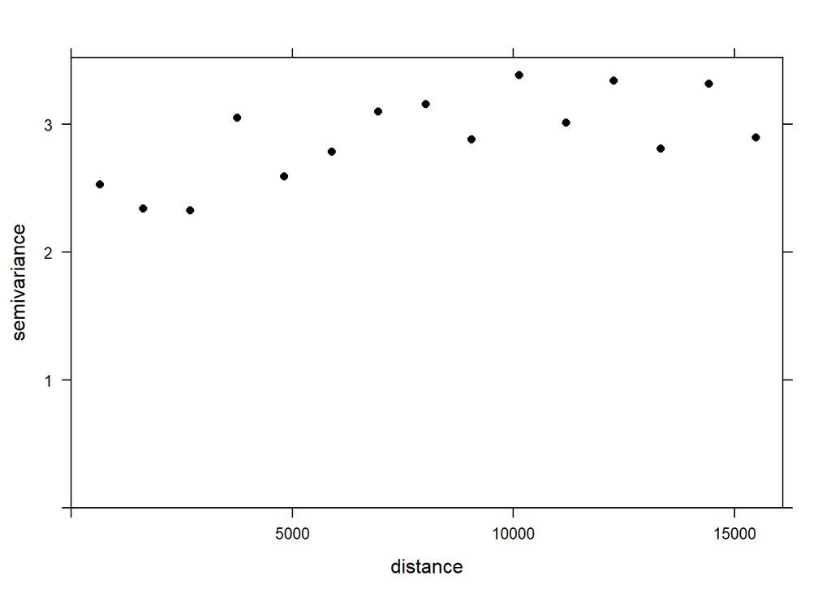

It looks like there is relatively little spatial auto-correlation in the model residuals so I will not include a spatial term for the time being.

## 6

Next, I needed to check the model’s diagnostic plots.

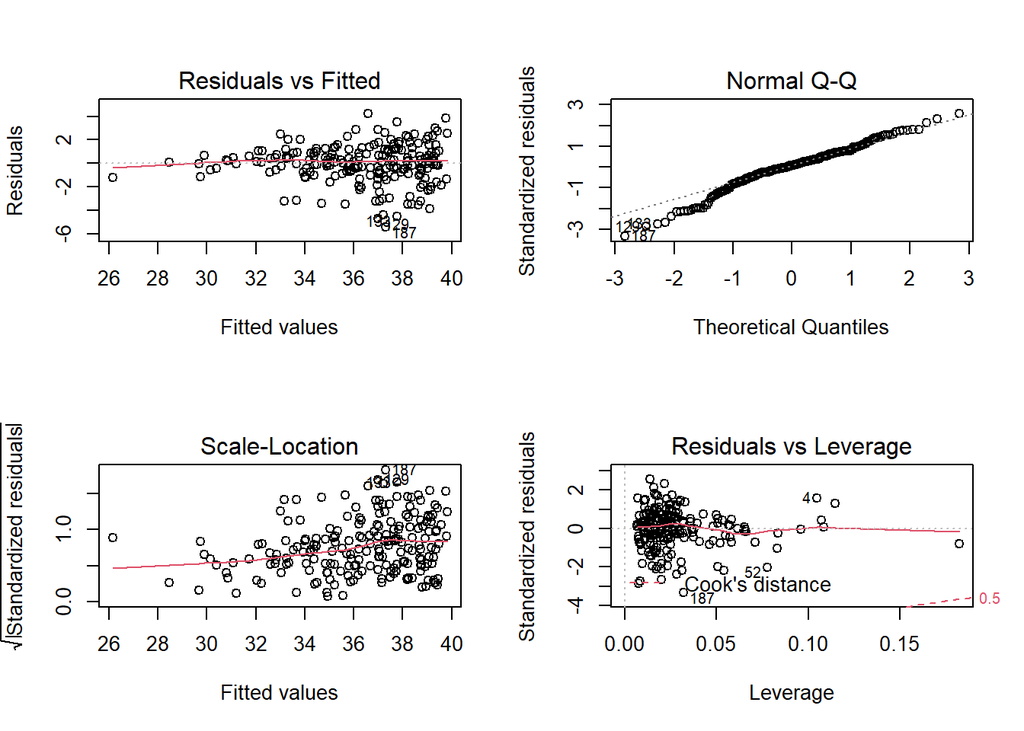

```r
par(mfrow=c(2,2))
plot(lst.model)
```

These plots look pretty good, meaning that the model should be valid.

Based on this, it seems that LST is being mainly determined by a combination of building density and canopy cover. However, not all areas of low building density necessarily have high canopy cover. Because of this, impervious cover is also an important factor to a slightly lesser extent. Distance to the river is also an important factor due to the temperature regulating properties of large bodies of water. Income is also a strong predictor variable in this model. I would normally assume that this is because of higher canopy cover and more green space in high income areas. But, in the initial data exploration I found relatively little correlation between income and canopy cover and even less correlation between income and proximity to green spaces. It seems that income must be affecting the physical environment more in terms of general greenness and NDVI than the specific ES indicators I selected.

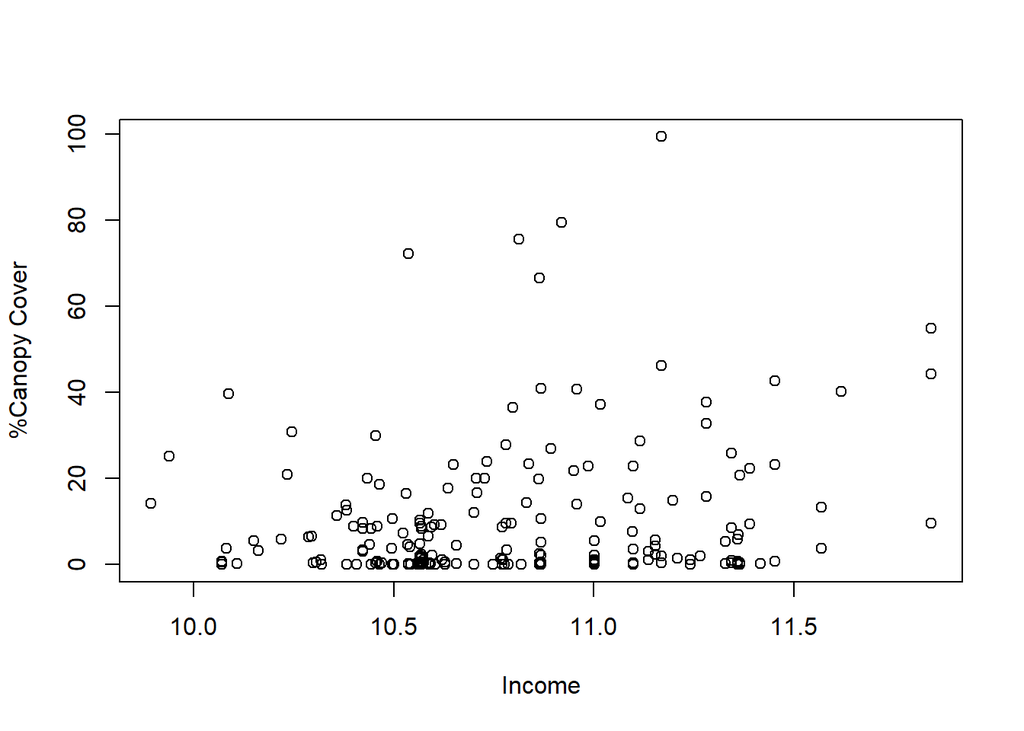

```r
plot(X.canopy~log(Income), data=lst.data, xlab="Income", ylab="%Canopy Cover")
```

# NO2 Exploration

## 1

I started out by making a correlation matrix of all the variables I thought might be influencing NO2. The results of this were pretty unclear, with the exception that there was an obvious correlation between NO2 concentrations and distance from the large petrochemical facility.

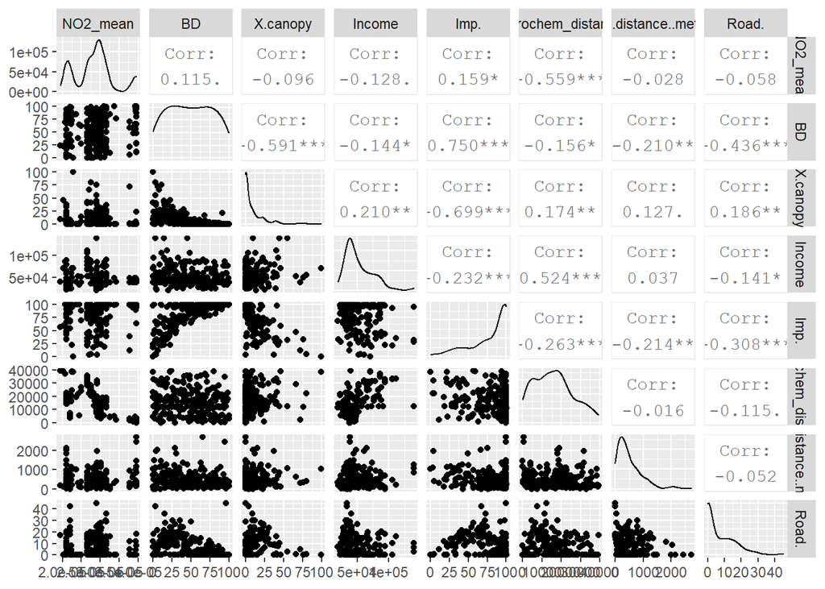

```r
no2.data<-read.csv("Data/shortlist_data_0813.csv")
library(GGally)
library(tidyverse)

data.selected<-no2.data%>%select(NO2_mean,BD, X.canopy,
                                 Income,Imp., petrochem_distance, road.distance..meters.,
                                 Road.)
GGally::ggpairs(data.selected)
```

## 2

I decided to try modelling this indicator as a GAM. I started with the model:

```r
library(mgcv)
no2.gam<-gam(NO2_mean~s(BD)+s(X.canopy)+s(Income)+s(Imp.)+s(petrochem_distance)+
               s(road.distance..meters.)+s(Road.), data=no2.data, method="REML")
summary(no2.gam)
```

```
##
## Family: gaussian
## Link function: identity
##
## Formula:
## NO2_mean ~ s(BD) + s(X.canopy) + s(Income) + s(Imp.) + s(petrochem_distance) +
##     s(road.distance..meters.) + s(Road.)
##
## Parametric coefficients:
##              Estimate Std. Error t value Pr(>|t|)
## (Intercept) 2.837e-05  2.229e-07   127.2   <2e-16 ***
## ---
## Signif. codes:  0 '***' 0.001 '**' 0.01 '*' 0.05 '.' 0.1 ' ' 1
##
## Approximate significance of smooth terms:
##                             edf Ref.df      F p-value
## s(BD)                     1.000  1.000  0.860 0.35470
## s(X.canopy)               1.000  1.001  0.336 0.56294
## s(Income)                 2.589  3.234  4.279 0.00619 **
## s(Imp.)                   1.002  1.005  0.171 0.68219
## s(petrochem_distance)     7.357  8.333 33.138 < 2e-16 ***
## s(road.distance..meters.) 1.000  1.000  5.734 0.01752 *
## s(Road.)                  1.000  1.000  0.805 0.37066
## ---
## Signif. codes:  0 '***' 0.001 '**' 0.01 '*' 0.05 '.' 0.1 ' ' 1
##
## R-sq.(adj) =  0.581   Deviance explained =   61%
## -REML = -2342.2  Scale est. = 1.0933e-11  n = 220
```

## 3

Next, I tried adding in a couple interaction terms that I thought might be important. The ones I tried were: `ti(petrochem_distance, Income)`, `ti(X.canopy,BD)` and `ti(X.canopy, Imp.)`.

```r
no2.gam2<-gam(NO2_mean~s(BD)+s(X.canopy)+s(Imp.)+s(petrochem_distance)+s(Income)+
                s(road.distance..meters.)+s(Road.)+ti(petrochem_distance, Income), data=no2.data, method="REML")
summary(no2.gam2)
```

```
##
## Family: gaussian
## Link function: identity
##
## Formula:
## NO2_mean ~ s(BD) + s(X.canopy) + s(Imp.) + s(petrochem_distance) +
##     s(Income) + s(road.distance..meters.) + s(Road.) + ti(petrochem_distance,
##     Income)
##
## Parametric coefficients:
##              Estimate Std. Error t value Pr(>|t|)
## (Intercept) 2.861e-05  3.299e-07   86.74   <2e-16 ***
## ---
## Signif. codes:  0 '***' 0.001 '**' 0.01 '*' 0.05 '.' 0.1 ' ' 1
##
## Approximate significance of smooth terms:
##                                 edf Ref.df      F p-value
## s(BD)                         1.000  1.000  0.917 0.33929
## s(X.canopy)                   1.001  1.001  0.345 0.55801
## s(Imp.)                       1.002  1.003  0.156 0.69489
## s(petrochem_distance)         7.325  8.306 31.964 < 2e-16 ***
## s(Income)                     2.501  3.124  4.676 0.00387 **
## s(road.distance..meters.)     1.000  1.001  6.253 0.01316 *
## s(Road.)                      1.001  1.001  0.684 0.40939
## ti(petrochem_distance,Income) 1.001  1.001  1.048 0.30716
## ---
## Signif. codes:  0 '***' 0.001 '**' 0.01 '*' 0.05 '.' 0.1 ' ' 1
##
## R-sq.(adj) =  0.582   Deviance explained = 61.2%
## -REML = -2331.6  Scale est. = 1.0908e-11  n = 220
```

```r
no2.gam3<-gam(NO2_mean~s(BD)+s(X.canopy)+s (Imp.)+s(petrochem_distance)+s(Income)+
                s(road.distance..meters.)+s(Road.)+
                ti(X.canopy, Imp.), data=no2.data, method="REML")
summary(no2.gam3)
```

```
##
## Family: gaussian
## Link function: identity
##
## Formula:
## NO2_mean ~ s(BD) + s(X.canopy) + s(Imp.) + s(petrochem_distance) +
##     s(Income) + s(road.distance..meters.) + s(Road.) + ti(X.canopy,
##     Imp.)
##
## Parametric coefficients:
##              Estimate Std. Error t value Pr(>|t|)
## (Intercept) 2.849e-05  2.895e-07   98.41   <2e-16 ***
## ---
## Signif. codes:  0 '***' 0.001 '**' 0.01 '*' 0.05 '.' 0.1 ' ' 1
##
## Approximate significance of smooth terms:
##                             edf Ref.df      F p-value
## s(BD)                     1.000  1.000  1.003  0.3177
## s(X.canopy)               1.001  1.001  0.661  0.4170
## s(Imp.)                   2.097  2.681  0.368  0.6190
## s(petrochem_distance)     7.328  8.308 32.537  <2e-16 ***
## s(Income)                 2.543  3.175  4.288  0.0061 **
## s(road.distance..meters.) 1.000  1.000  5.900  0.0160 *
## s(Road.)                  1.001  1.001  0.418  0.5193
## ti(X.canopy,Imp.)         1.002  1.005  0.432  0.5131
## ---
## Signif. codes:  0 '***' 0.001 '**' 0.01 '*' 0.05 '.' 0.1 ' ' 1
##
## R-sq.(adj) =  0.582   Deviance explained = 61.5%
## -REML = -2330.9  Scale est. = 1.0904e-11  n = 220
```

```r
no2.gam.x<-gam(NO2_mean~s(BD)+s(X.canopy)+s (Imp.)+s(petrochem_distance)+s(Income)+
                s(road.distance..meters.)+s(Road.)+
                ti(X.canopy, BD), data=no2.data, method="REML")
summary(no2.gam.x)
```

```
##
## Family: gaussian
## Link function: identity
##
## Formula:
## NO2_mean ~ s(BD) + s(X.canopy) + s(Imp.) + s(petrochem_distance) +
##     s(Income) + s(road.distance..meters.) + s(Road.) + ti(X.canopy,
##     BD)
##
## Parametric coefficients:
##              Estimate Std. Error t value Pr(>|t|)
## (Intercept) 2.807e-05  3.842e-07   73.05   <2e-16 ***
## ---
## Signif. codes:  0 '***' 0.001 '**' 0.01 '*' 0.05 '.' 0.1 ' ' 1
##
## Approximate significance of smooth terms:
##                             edf Ref.df      F p-value
## s(BD)                     4.031  4.996  1.275 0.25694
## s(X.canopy)               1.002  1.003  0.380 0.53956
## s(Imp.)                   1.001  1.001  0.202 0.65444
## s(petrochem_distance)     7.448  8.388 32.797 < 2e-16 ***
## s(Income)                 2.615  3.262  4.168 0.00724 **
## s(road.distance..meters.) 1.000  1.000  5.100 0.02498 *
## s(Road.)                  1.000  1.001  1.091 0.29759
## ti(X.canopy,BD)           1.002  1.003  0.885 0.34781
## ---
## Signif. codes:  0 '***' 0.001 '**' 0.01 '*' 0.05 '.' 0.1 ' ' 1
##
## R-sq.(adj) =  0.595   Deviance explained =   63%
## -REML = -2331.5  Scale est. = 1.058e-11  n = 220
```

All interaction terms have very high p values so I did not use either. To double check that this was the right decision, I did some model camparisons:

```r
anova(no2.gam, no2.gam2, test="Chisq")
```

```
## Analysis of Deviance Table
##
## Model 1: NO2_mean ~ s(BD) + s(X.canopy) + s(Income) + s(Imp.) + s(petrochem_distance) +
##     s(road.distance..meters.) + s(Road.)
## Model 2: NO2_mean ~ s(BD) + s(X.canopy) + s(Imp.) + s(petrochem_distance) +
##     s(Income) + s(road.distance..meters.) + s(Road.) + ti(petrochem_distance,
##     Income)
##   Resid. Df Resid. Dev      Df   Deviance Pr(>Chi)
## 1    201.41 2.2310e-09
## 2    200.61 2.2162e-09 0.79546 1.4803e-11    0.189
```

```r
anova(no2.gam, no2.gam3, test="Chisq")
```

```
## Analysis of Deviance Table
##
## Model 1: NO2_mean ~ s(BD) + s(X.canopy) + s(Income) + s(Imp.) + s(petrochem_distance) +
##     s(road.distance..meters.) + s(Road.)
## Model 2: NO2_mean ~ s(BD) + s(X.canopy) + s(Imp.) + s(petrochem_distance) +
##     s(Income) + s(road.distance..meters.) + s(Road.) + ti(X.canopy,
##     Imp.)
##   Resid. Df Resid. Dev     Df   Deviance Pr(>Chi)
## 1    201.41 2.2310e-09
## 2    197.63 2.2029e-09 3.7786 2.8047e-11   0.5969
```

```r
AIC(no2.gam, no2.gam2, no2.gam3)
```

```
##                df       AIC
## no2.gam  17.96983 -4908.910
## no2.gam2 18.78065 -4908.753
## no2.gam3 21.17143 -4905.290
```

The results of these comparisons confirm that the interaction terms were not significant to the model.

## 4

Next, I tried removing variables one by one from the model to see if a simpler model might be better. I knew I either wanted to remove Road% or distance to the nearest road since they both measure the presence of roads as a variable.

```r
no2.gam4<-gam(NO2_mean~s(BD)+s(X.canopy)+s(Income)+s(Imp.)+s(petrochem_distance)+
                s(Road.), data=no2.data, method="REML")
no2.gam5<-gam(NO2_mean~s(BD)+s(X.canopy)+s(Income)+s(Imp.)+s(petrochem_distance)+
                s(road.distance..meters.), data=no2.data, method="REML")
anova(no2.gam, no2.gam4, test="Chisq")
```

```
## Analysis of Deviance Table
##
## Model 1: NO2_mean ~ s(BD) + s(X.canopy) + s(Income) + s(Imp.) + s(petrochem_distance) +
##     s(road.distance..meters.) + s(Road.)
## Model 2: NO2_mean ~ s(BD) + s(X.canopy) + s(Income) + s(Imp.) + s(petrochem_distance) +
##     s(Road.)
##   Resid. Df Resid. Dev      Df    Deviance Pr(>Chi)
## 1    201.41  2.231e-09
## 2    202.67  2.305e-09 -1.2625 -7.4069e-11  0.01393 *
## ---
## Signif. codes:  0 '***' 0.001 '**' 0.01 '*' 0.05 '.' 0.1 ' ' 1
```

```r
anova(no2.gam, no2.gam5, test="Chisq")
```

```
## Analysis of Deviance Table
##
## Model 1: NO2_mean ~ s(BD) + s(X.canopy) + s(Income) + s(Imp.) + s(petrochem_distance) +
##     s(road.distance..meters.) + s(Road.)
## Model 2: NO2_mean ~ s(BD) + s(X.canopy) + s(Income) + s(Imp.) + s(petrochem_distance) +
##     s(road.distance..meters.)
##   Resid. Df Resid. Dev      Df    Deviance Pr(>Chi)
## 1    201.41 2.2310e-09
## 2    200.86 2.2328e-09 0.54553 -1.8083e-12
```

```r
AIC(no2.gam,no2.gam4,no2.gam5)
```

```
##                df       AIC
## no2.gam  17.96983 -4908.910
## no2.gam4 16.69505 -4904.274
## no2.gam5 18.22665 -4908.218
```

By removing the %road from the model but leaving in the distance to the nearest road, I was able to make the model simpler while maintaining the same AIC value.

Impervious cover and canopy cover were showing quite a bit of concurvity as well so I tried removing each one from the model in turn.

```r
concurvity(no2.gam, full=TRUE)
```

```
##                  para     s(BD) s(X.canopy) s(Income)   s(Imp.)
## worst    1.476031e-22 0.8305862   0.7962879 0.6757919 0.8420163
## observed 1.476031e-22 0.7551681   0.6870400 0.4603013 0.8223673
## estimate 1.476031e-22 0.7115619   0.6250921 0.5317757 0.7686608
##          s(petrochem_distance) s(road.distance..meters.)  s(Road.)
## worst                0.6683461                 0.5419978 0.7144699
## observed             0.4693674                 0.4249617 0.6663975
## estimate             0.5634103                 0.3598892 0.4951186
```

```r
no2.gam6<-gam(NO2_mean~s(BD)+s(X.canopy)+s(Income)+s(petrochem_distance)+
                s(road.distance..meters.), data=no2.data, method="REML")
anova(no2.gam5, no2.gam6, test="Chisq")
```

```
## Analysis of Deviance Table
##
## Model 1: NO2_mean ~ s(BD) + s(X.canopy) + s(Income) + s(Imp.) + s(petrochem_distance) +
##     s(road.distance..meters.)
## Model 2: NO2_mean ~ s(BD) + s(X.canopy) + s(Income) + s(petrochem_distance) +
##     s(road.distance..meters.)
##   Resid. Df Resid. Dev      Df    Deviance Pr(>Chi)
## 1    200.86 2.2328e-09
## 2    203.47 2.2439e-09 -2.6047 -1.1185e-11   0.7291
```

```r
AIC(no2.gam5, no2.gam6)
```

```
##                df       AIC
## no2.gam5 18.22665 -4908.218
## no2.gam6 15.90586 -4911.760
```

```r
#model that excludes imp. seems stronger

no2.gam7<-gam(NO2_mean~s(BD)+s(Income)+s(petrochem_distance)+
                s(road.distance..meters.), data=no2.data, method="REML")
anova(no2.gam6, no2.gam7, test="Chisq")
```

```
## Analysis of Deviance Table
##
## Model 1: NO2_mean ~ s(BD) + s(X.canopy) + s(Income) + s(petrochem_distance) +
##     s(road.distance..meters.)
## Model 2: NO2_mean ~ s(BD) + s(Income) + s(petrochem_distance) + s(road.distance..meters.)
##   Resid. Df Resid. Dev       Df    Deviance Pr(>Chi)
## 1    203.47 2.2439e-09
## 2    204.39 2.2529e-09 -0.92706 -8.9655e-12   0.3384
```

```r
AIC(no2.gam6, no2.gam7)
```

```
##                df       AIC
## no2.gam6 15.90586 -4911.760
## no2.gam7 14.98298 -4912.729
```

```r
#model excluding canopy cover is slightly stronger
```

## 5

The next step was to check for spatial autocorrelation in the model residuals using a semivariogram.

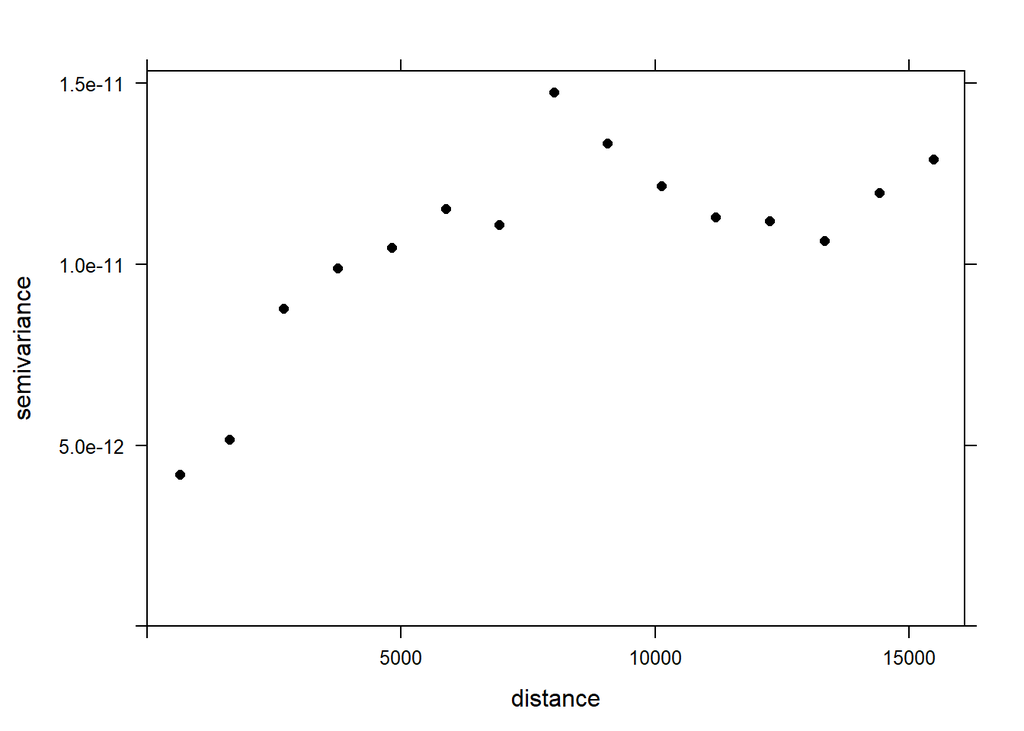

```r
library(nlme)
library(gstat)
library(sp)
library(ape)

no2.modelspace<-gam(NO2_mean~s(BD)+s(petrochem_distance)+s(X.canopy)+
                      s(road.distance..meters.), data=no2.data, method="REML")
coordinates(no2.data)<-c('Long','Lat')
resids<-residuals(no2.modelspace)
no2.data$resids=resids
V<-variogram(resids~1, data=no2.data)
plot(V, pch=16, col="black")
```

It is quite clear from this plot that spatial autocorrelation is an issue.

## 6

With this in mind, I added a spatial term to the model.

```r
no2.gam8<-gam(NO2_mean~s(BD)+s(Income)+s(petrochem_distance)+s(X.canopy)+
                s(road.distance..meters.)+s(Lat,Long), data=no2.data, method="REML")
summary(no2.gam8)
```

```
##
## Family: gaussian
## Link function: identity
##
## Formula:
## NO2_mean ~ s(BD) + s(Income) + s(petrochem_distance) + s(X.canopy) +
##     s(road.distance..meters.) + s(Lat, Long)
##
## Parametric coefficients:
##              Estimate Std. Error t value Pr(>|t|)
## (Intercept) 2.837e-05  1.183e-07   239.8   <2e-16 ***
## ---
## Signif. codes:  0 '***' 0.001 '**' 0.01 '*' 0.05 '.' 0.1 ' ' 1
##
## Approximate significance of smooth terms:
##                              edf Ref.df      F p-value
## s(BD)                      1.195  1.363  0.319 0.56926
## s(Income)                  2.244  2.802  4.506 0.00672 **
## s(petrochem_distance)      1.000  1.000  4.914 0.02780 *
## s(X.canopy)                1.002  1.003  1.602 0.20702
## s(road.distance..meters.)  1.001  1.001  1.774 0.18431
## s(Lat,Long)               26.533 28.354 33.315 < 2e-16 ***
## ---
## Signif. codes:  0 '***' 0.001 '**' 0.01 '*' 0.05 '.' 0.1 ' ' 1
##
## R-sq.(adj) =  0.882   Deviance explained =   90%
## -REML = -2445.7  Scale est. = 3.078e-12  n = 220
```

```r
anova(no2.gam6, no2.gam8)
```

```
## Analysis of Deviance Table
##
## Model 1: NO2_mean ~ s(BD) + s(X.canopy) + s(Income) + s(petrochem_distance) +
##     s(road.distance..meters.)
## Model 2: NO2_mean ~ s(BD) + s(Income) + s(petrochem_distance) + s(X.canopy) +
##     s(road.distance..meters.) + s(Lat, Long)
##   Resid. Df Resid. Dev     Df   Deviance
## 1    203.47 2.2439e-09
## 2    180.93 5.7259e-10 22.539 1.6714e-09
```

```r
AIC(no2.gam6, no2.gam8)
```

```
##                df       AIC
## no2.gam6 15.90586 -4911.760
## no2.gam8 37.52354 -5169.006
```

The spatial model is clearly stronger than the non-spatial model.

## 7

Next, I did some diagnostics to check this model’s validity

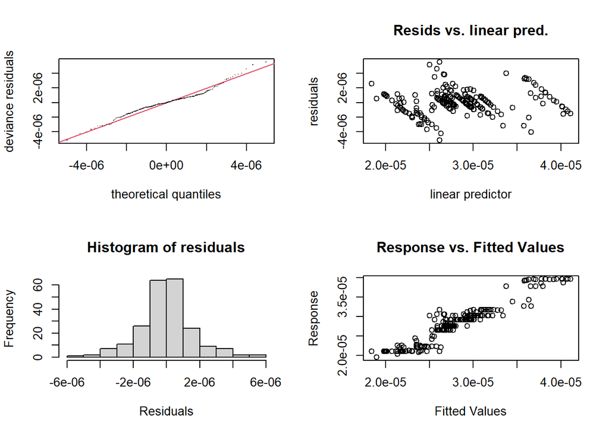

```
##
## Method: REML   Optimizer: outer newton
## full convergence after 8 iterations.
## Gradient range [-0.0005275412,0.001245007]
## (score -2445.697 & scale 3.078007e-12).
## Hessian positive definite, eigenvalue range [3.767607e-05,107.5576].
## Model rank =  75 / 75
##
## Basis dimension (k) checking results. Low p-value (k-index<1) may
## indicate that k is too low, especially if edf is close to k'.
##
##                              k'   edf k-index p-value
## s(BD)                      9.00  1.19    0.88   0.055 .
## s(Income)                  9.00  2.24    1.18   0.990
## s(petrochem_distance)      9.00  1.00    1.14   0.980
## s(X.canopy)                9.00  1.00    1.01   0.440
## s(road.distance..meters.)  9.00  1.00    0.96   0.310
## s(Lat,Long)               29.00 26.53    0.79   0.005 **
## ---
## Signif. codes:  0 '***' 0.001 '**' 0.01 '*' 0.05 '.' 0.1 ' ' 1
```

```r
gam.check(no2.gam8)
```

```r
concurvity(no2.gam8)
```

```
##                  para     s(BD) s(Income) s(petrochem_distance) s(X.canopy)
## worst    8.656247e-21 0.7583704 0.8244705             0.9999966   0.7756897
## observed 8.656247e-21 0.7314330 0.7093987             0.9999511   0.6756053
## estimate 8.656247e-21 0.6697909 0.6812518             0.9994227   0.5654900
##          s(road.distance..meters.) s(Lat,Long)
## worst                    0.8085522   0.9999966
## observed                 0.7188870   0.9689148
## estimate                 0.7110598   0.7669393
```

There was high concurvity between petrochem_distance and the spatial term. I tried removing the petrochem_distance from the model to get rid of the concurvity.

```r
no2.gam9<-gam(NO2_mean~s(BD)+s(Income)+s(X.canopy)+
                s(road.distance..meters.)+s(Lat,Long), data=no2.data, method="REML")
summary(no2.gam9)
```

```
##
## Family: gaussian
## Link function: identity
##
## Formula:
## NO2_mean ~ s(BD) + s(Income) + s(X.canopy) + s(road.distance..meters.) +
##     s(Lat, Long)
##
## Parametric coefficients:
##              Estimate Std. Error t value Pr(>|t|)
## (Intercept) 2.837e-05  1.192e-07     238   <2e-16 ***
## ---
## Signif. codes:  0 '***' 0.001 '**' 0.01 '*' 0.05 '.' 0.1 ' ' 1
##
## Approximate significance of smooth terms:
##                              edf Ref.df      F p-value
## s(BD)                      1.357  1.631  0.338 0.57375
## s(Income)                  2.196  2.744  4.303 0.00913 **
## s(X.canopy)                1.004  1.008  1.870 0.17252
## s(road.distance..meters.)  1.631  2.027  0.992 0.36503
## s(Lat,Long)               27.074 28.733 52.220 < 2e-16 ***
## ---
## Signif. codes:  0 '***' 0.001 '**' 0.01 '*' 0.05 '.' 0.1 ' ' 1
##
## R-sq.(adj) =   0.88   Deviance explained = 89.8%
## -REML = -2454.3  Scale est. = 3.1254e-12  n = 220
```

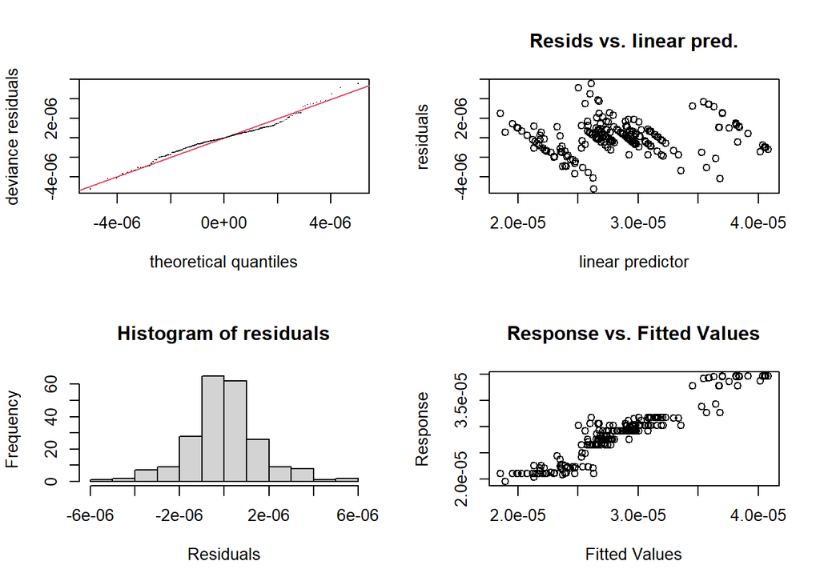

```
##
## Method: REML   Optimizer: outer newton
## full convergence after 8 iterations.
## Gradient range [-0.001210265,0.0007866005]
## (score -2454.298 & scale 3.12542e-12).
## Hessian positive definite, eigenvalue range [0.001209004,108.1279].
## Model rank =  66 / 66
##
## Basis dimension (k) checking results. Low p-value (k-index<1) may
## indicate that k is too low, especially if edf is close to k'.
##
##                              k'   edf k-index p-value
## s(BD)                      9.00  1.36    0.89   0.055 .
## s(Income)                  9.00  2.20    1.18   0.995
## s(X.canopy)                9.00  1.00    1.00   0.525
## s(road.distance..meters.)  9.00  1.63    0.96   0.290
## s(Lat,Long)               29.00 27.07    0.79  <2e-16 ***
## ---
## Signif. codes:  0 '***' 0.001 '**' 0.01 '*' 0.05 '.' 0.1 ' ' 1
```

```r
gam.check(no2.gam9)
```

```r
concurvity(no2.gam9)
```

```
##                  para     s(BD) s(Income) s(X.canopy) s(road.distance..meters.)
## worst    1.582915e-21 0.7374052 0.7948940   0.7537346                 0.6356874
## observed 1.582915e-21 0.7115630 0.6892404   0.6480750                 0.4690740
## estimate 1.582915e-21 0.6529731 0.6465659   0.5318565                 0.5566792
##          s(Lat,Long)
## worst      0.7996581
## observed   0.3786431
## estimate   0.3977348
```

When I compared the model with petrochem_distance to the one without it, the model including petrochem_distance had a lower AIC value and came up as stronger in the anova().

```r
anova(no2.gam8, no2.gam9, test="Chisq")
```

```
## Analysis of Deviance Table
##
## Model 1: NO2_mean ~ s(BD) + s(Income) + s(petrochem_distance) + s(X.canopy) +
##     s(road.distance..meters.) + s(Lat, Long)
## Model 2: NO2_mean ~ s(BD) + s(Income) + s(X.canopy) + s(road.distance..meters.) +
##     s(Lat, Long)
##   Resid. Df Resid. Dev      Df    Deviance Pr(>Chi)
## 1    180.93 5.7259e-10
## 2    179.98 5.8051e-10 0.95004 -7.9185e-12
```

```r
AIC(no2.gam8, no2.gam9)
```

```
##                df       AIC
## no2.gam8 37.52354 -5169.006
## no2.gam9 38.14277 -5164.746
```

In the end, after doing some reading on the subject, I don’t think it’s appropriate to include the petrochemical distance in the model for the following reasons: a) The concurvity was >0.99, b) The spatial term measures essentially the same thing as the petrochem_distance term (they both measure the geographic location of sites, just with different units of measurement) so I would essentially be including the same term twice, c) the ultimate reason why the distance to the petrochemical facility matters is that sites that are closer to it would display more similar (higher) values (Tobler’s law). This issue is what using the spatial term is correcting for, so it makes it unnecessary to include the petrochem_distance term. These are the diagnostic plots for the model with no petrochem_distance term after adjusting for the initial `gam.check()` results:

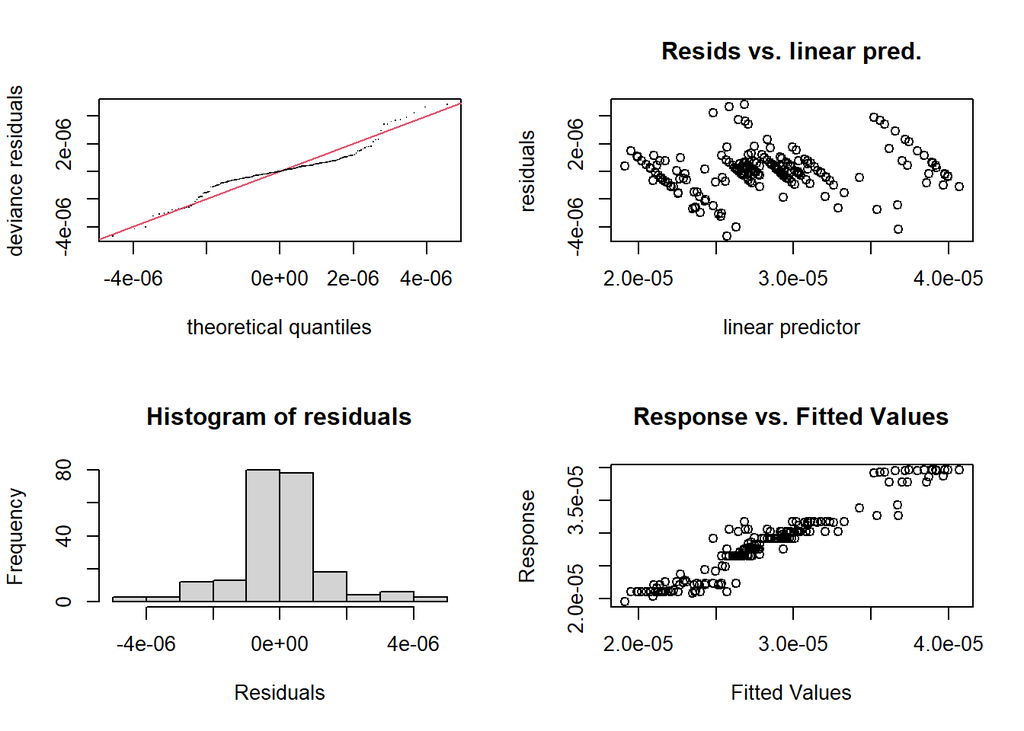

```
##
## Method: REML   Optimizer: outer newton
## full convergence after 6 iterations.
## Gradient range [-0.0008504399,0.0011578]
## (score -2471.392 & scale 2.589232e-12).
## Hessian positive definite, eigenvalue range [0.0001717264,112.7185].
## Model rank =  92 / 92
##
## Basis dimension (k) checking results. Low p-value (k-index<1) may
## indicate that k is too low, especially if edf is close to k'.
##
##                              k'   edf k-index p-value
## s(BD)                      9.00  1.00    0.90   0.065 .
## s(Income)                  9.00  1.75    1.28   1.000
## s(road.distance..meters.)  9.00  1.00    0.97   0.295
## s(Lat,Long)               64.00 48.45    0.92   0.120
## ---
## Signif. codes:  0 '***' 0.001 '**' 0.01 '*' 0.05 '.' 0.1 ' ' 1
```

```r
no2.gam10<-gam(NO2_mean~s(BD)+s(Income)+s(road.distance..meters.)+
                 s(Lat,Long, k=65), data=no2.data, method="REML")
gam.check(no2.gam10)
```

## 8

The problem with the above model is that it accounts for spatial autocorrelation but doesn’t allow me to see the true effects of the other variables in the model. Because of this, I tried applying the Spatial+ approach:

```r
BD_gam<- gam(BD~s(Lat*Long), data=no2.data)
resid_BD<-residuals(BD_gam)
income_gam<-gam(log(Income)~s(Lat*Long), data=no2.data, na.action=na.exclude)
resid_income<-residuals(income_gam)
road_gam<-gam(log(road.distance..meters.)~s(Lat*Long), data=no2.data)
resid_road<-residuals(road_gam)
canopy_gam<-gam(X.canopy~s(Lat*Long), data=no2.data)
resid_canopy<-residuals(canopy_gam)

no2.gam11<-gam(NO2_mean~resid_BD+resid_income+resid_road+resid_canopy+s(Lat,Long), data=no2.data,
               method="REML")
summary(no2.gam11)
```

```
##
## Family: gaussian
## Link function: identity
##
## Formula:
## NO2_mean ~ resid_BD + resid_income + resid_road + resid_canopy +
##     s(Lat, Long)
##
## Parametric coefficients:
##               Estimate Std. Error t value Pr(>|t|)
## (Intercept)  2.836e-05  1.191e-07 238.152  < 2e-16 ***
## resid_BD     2.708e-09  5.786e-09   0.468  0.64028
## resid_income 1.488e-06  4.817e-07   3.089  0.00231 **
## resid_road   2.696e-07  1.328e-07   2.030  0.04375 *
## resid_canopy 1.117e-08  1.118e-08   0.999  0.31931
## ---
## Signif. codes:  0 '***' 0.001 '**' 0.01 '*' 0.05 '.' 0.1 ' ' 1
##
## Approximate significance of smooth terms:
##               edf Ref.df     F p-value
## s(Lat,Long) 27.14  28.78 54.67  <2e-16 ***
## ---
## Signif. codes:  0 '***' 0.001 '**' 0.01 '*' 0.05 '.' 0.1 ' ' 1
##
## R-sq.(adj) =  0.881   Deviance explained = 89.8%
## -REML = -2450.9  Scale est. = 3.1141e-12  n = 220
```

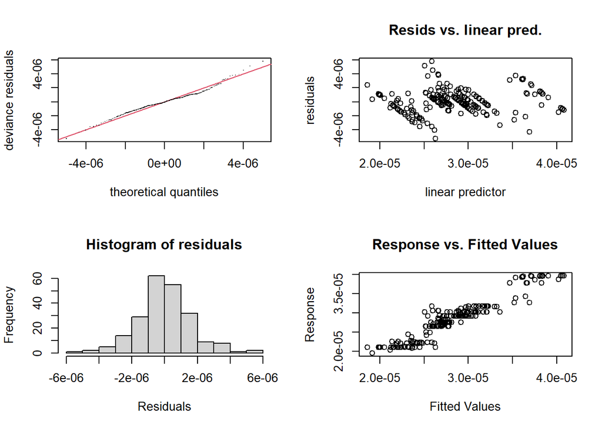

```
##
## Method: REML   Optimizer: outer newton
## full convergence after 5 iterations.
## Gradient range [-2.238681e-06,1.655551e-06]
## (score -2450.855 & scale 3.114076e-12).
## Hessian positive definite, eigenvalue range [9.728551,108.1329].
## Model rank =  34 / 34
##
## Basis dimension (k) checking results. Low p-value (k-index<1) may
## indicate that k is too low, especially if edf is close to k'.
##
##               k'  edf k-index p-value
## s(Lat,Long) 29.0 27.1    0.78  <2e-16 ***
## ---
## Signif. codes:  0 '***' 0.001 '**' 0.01 '*' 0.05 '.' 0.1 ' ' 1
```

```r
gam.check(no2.gam11)
```

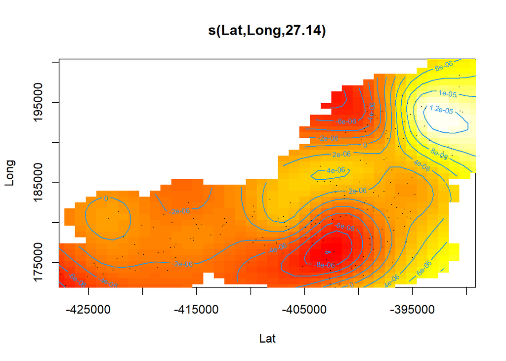

```r
plot(no2.gam11, scheme=2, page=1)
```

```r
concurvity(no2.gam11)
```

```
##                 para s(Lat,Long)
## worst    0.001801102  0.44963153
## observed 0.001801102  0.01618789
## estimate 0.001801102  0.02301975
```

I also tried a version of this model using Borough as a random effect:

```r
Boroughs<-as.factor(no2.data$Borough)

##tring borough as random effect
no2.gam12<-gam(NO2_mean~s(BD)+s(Income)+s(road.distance..meters.)+s(X.canopy)+
                  s(Boroughs, bs="re"), data=no2.data, method="REML", na.action=na.exclude)
summary(no2.gam12)
```

```
##
## Family: gaussian
## Link function: identity
##
## Formula:
## NO2_mean ~ s(BD) + s(Income) + s(road.distance..meters.) + s(X.canopy) +
##     s(Boroughs, bs = "re")
##
## Parametric coefficients:
##              Estimate Std. Error t value Pr(>|t|)
## (Intercept) 2.784e-05  8.326e-07   33.44   <2e-16 ***
## ---
## Signif. codes:  0 '***' 0.001 '**' 0.01 '*' 0.05 '.' 0.1 ' ' 1
##
## Approximate significance of smooth terms:
##                              edf Ref.df      F p-value
## s(BD)                      1.000  1.000  0.276   0.600
## s(Income)                  1.002  1.003  0.378   0.540
## s(road.distance..meters.)  1.000  1.001  1.026   0.312
## s(X.canopy)                1.000  1.000  0.823   0.365
## s(Boroughs)               30.960 33.000 20.493  <2e-16 ***
## ---
## Signif. codes:  0 '***' 0.001 '**' 0.01 '*' 0.05 '.' 0.1 ' ' 1
##
## R-sq.(adj) =   0.76   Deviance explained = 79.8%
## -REML = -2405.5  Scale est. = 6.2653e-12  n = 220
```

```r
##trying both approaches together
no2.gam13<-gam(NO2_mean~resid_BD+resid_income+resid_road+resid_canopy
               +s(Lat,Long)+s(Boroughs, bs="re"), data=no2.data,
               method="REML")
summary(no2.gam13)
```

```
##
## Family: gaussian
## Link function: identity
##
## Formula:
## NO2_mean ~ resid_BD + resid_income + resid_road + resid_canopy +
##     s(Lat, Long) + s(Boroughs, bs = "re")
##
## Parametric coefficients:
##               Estimate Std. Error t value Pr(>|t|)
## (Intercept)  2.836e-05  1.191e-07 238.013  < 2e-16 ***
## resid_BD     2.708e-09  5.786e-09   0.468  0.64034
## resid_income 1.488e-06  4.818e-07   3.088  0.00232 **
## resid_road   2.696e-07  1.328e-07   2.031  0.04371 *
## resid_canopy 1.116e-08  1.118e-08   0.998  0.31942
## ---
## Signif. codes:  0 '***' 0.001 '**' 0.01 '*' 0.05 '.' 0.1 ' ' 1
##
## Approximate significance of smooth terms:
##                  edf Ref.df     F p-value
## s(Lat,Long) 27.14014  28.77 54.62  <2e-16 ***
## s(Boroughs)  0.01362  33.00  0.00   0.482
## ---
## Signif. codes:  0 '***' 0.001 '**' 0.01 '*' 0.05 '.' 0.1 ' ' 1
##
## R-sq.(adj) =  0.881   Deviance explained = 89.8%
## -REML = -2450.9  Scale est. = 3.1139e-12  n = 220
```

The model using spatial+ but not using boroughs as a random effect seems to be best (once spatial+ was applied, adding in the random effect did not change the model)